# Introduction to Movement Metrics

Wenjing Xu 徐雯靓 (wenjing.xu@senckenberg.de)

21 July 2025

# Introduction

This session introduces core movement metrics that allow us to transform raw tracking data into biologically meaningful insights. By calculating and interpreting metrics such as speed, turning angle, and displacement, we begin to characterize movement strategies and behavioral patterns. These metrics also form the foundation for more advanced analyses, from modeling behavioral states to inferring habitat preferences and assessing landscape connectivity.

We will use `move2`(https://cran.r-project.org/web/packages/move2/index.html) and `amt` (https://cran.r-project.org/web/packages/amt/index.html) as example to see how some of the most frequently used metrics can be calculated.

In this exercise, we will cover:

1. Data exploration and step-level metrics with `move2`
   - data exploration
   - step length, speed, and turning angle
2. Step-level metrics with `amt`
   - data cleaning
   - calculating step length, speed, and turning angle
   - turn angle correlation (tac), straightness, intensity_use, net-squared displacement (NSD)
   - manipulating multiple individuals

## Load Libraries

Load the required libraries and remove everything held in [R’s](https://cran.r-project.org/) memory.

```r
library(tidyverse, quietly = TRUE) #the tidyverse is an collection of R packages designed for data science. All packages share an underlying design philosophy, grammar, and data structures. Relavant packages for us includ `dplyr` (for data manipulation), `lubridate` (for dealing with time), `ggplot2` (for data visualization).
library(sf, quietly = TRUE) #"simple features", lets us work with spatial vector data
library(amt, quietly = TRUE) # amt = animal movement tool. It is used to manage and analyze animal movement data. It can be used to calculate home range, track statistics, and prep the data for further analysis such as resource selection function (which you will learn more on day 3)
library(move2, quietly = TRUE) #handle, manipulate, and explore trajectory data with direct connection with MOVEBANK and sf
library(units, quietly = TRUE) #support for measurement units
library(rnaturalearth, quietly = TRUE)
library(gridExtra, quietly = TRUE)
library(leaflet,quietly = TRUE) # to create interactive maps
```

# Step-level metrics with `move2`

One of the key strengths of `move2` is its native integration with Movebank (https://www.movebank.org/cms/movebank-main), a global platform for storing, managing, and sharing animal tracking data. Movebank provides a standardized and secure environment for trajectory data management, ensuring data quality, metadata consistency, and long-term accessibility. By linking directly to Movebank, `move2` allows us to efficiently import, explore, and analyze tracking datasets in a reproducible workflow—bridging robust data management with flexible analytical tools in R.

Movebank allows data owners to control access to their tracking data through customizable permissions. Users can choose to make their data fully public, viewable but not downloadable, or completely private—facilitating data sharing while respecting ownership and confidentiality.

Let’s try to use move2 to download and explore a public cougar dataset from Brazil (movebank study id 577226894):

Cavalcanti, S.M.C., Morato, R.G., Niebuhr, B.B. et al. 2021. A Onca-Parda na Bacia do Rio Tietê: O uso de um predador de topo de cadeia como ferramenta de conservacão da biodiversidade no Estado de Sao Paulo. Instituto para a Conservação dos Carnívoros Neotropicais (Pró-Carnívoros). Atibaia, São Paulo, Marco de 2021.

## read data

First we need to set our movebank login (sign up here https://www.movebank.org/cms/movebank-registration). You only need to do it once and your computer will remember it for the next time.

```r
movebank_store_credentials("myUserName", "myPassword") # replace user name and password with your own credentials
```

Then you can access a specific study with its ID number:

```r
dat.mv <- movebank_download_study(study_id = 577226894,
                        remove_movebank_outliers = T)
dat.mv
```

```
## A <move2> with `track_id_column` "individual_local_identifier" and
## `time_column` "timestamp"
## Containing 13 tracks lasting on average 229 days in a
## Simple feature collection with 55633 features and 10 fields
## Geometry type: POINT
## Dimension:     XY
## Bounding box:  xmin: -51.87212 ymin: -22.78902 xmax: -47.80087 ymax: -20.53535
## Geodetic CRS:  WGS 84
## # A tibble: 55,633 × 11
##    sensor_type_id individual_local_identifier behavioural_classificat…¹ comments
##           <int64> <fct>                       <fct>                     <chr>
##  1            653 Sucuri                      residency                 <NA>
##  2            653 Sucuri                      residency                 <NA>
##  3            653 Sucuri                      residency                 <NA>
##  4            653 Sucuri                      residency                 <NA>
##  5            653 Sucuri                      residency                 <NA>
##  6            653 Sucuri                      residency                 <NA>
##  7            653 Sucuri                      residency                 <NA>
##  8            653 Sucuri                      residency                 <NA>
##  9            653 Sucuri                      residency                 <NA>
## 10            653 Sucuri                      residency                 <NA>
## # ℹ 55,623 more rows
## # ℹ abbreviated name: ¹behavioural_classification
## # ℹ 7 more variables: gps_hdop [1], habitat <fct>, sampling_frequency [Hz],
## #   timestamp <dttm>, event_id <int64>, visible <lgl>, geometry <POINT [°]>
## First 10 track features:
## # A tibble: 13 × 51
##    deployment_id     tag_id individual_id animal_life_stage animal_mass
##          <int64>    <int64>       <int64> <fct>                     [g]
##  1    1783756613 1783745463    1783745462 36                      32000
##  2    1783756615 1783745481    1783745480 18                      31000
##  3    1783756616 1783745449    1783745454 48                      39000
##  4    1783756617 1783745456    1783745469 36                      41000
##  5    1783756619 1783745449    1783745448 48                      42000
##  6    1783756620 1783745477    1783745476 24                      31000
##  7    1783756621 1783745474    1783745487 24                      39000
##  8    1783756622 1783745463    1783745483 42                      45000
##  9    1783756623 1783745456    1783745455 30                      46000
## 10    1783756624 1783745485    1783745484 36                      42000
## # ℹ 3 more rows
## # ℹ 46 more variables: deploy_off_timestamp <dttm>, deploy_on_timestamp <dttm>,
## #   study_site <chr>, sensor_type_ids <chr>, capture_location <POINT [°]>,
## #   deploy_on_location <POINT [°]>, deploy_off_location <POINT [°]>,
## #   individual_comments <chr>, death_comments <chr>,
## #   individual_local_identifier <fct>, nick_name <fct>, sex <fct>,
## #   taxon_canonical_name <fct>, individual_number_of_deployments <int>, …
```

Data downloaded from movebank is a spatial object. It includes both track information (aka the metadata of each track) and an event table (with locations and timestamp). We can see that there are 13 tracks. Let’s visualize it:

```r
dat.lines <- dat.mv %>%
  mt_track_lines()

pal <- colorFactor(palette = "Set1", domain = dat.lines$individual_local_identifier)

dat.lines %>%
  leaflet() %>%
  addTiles() %>%
  addPolylines(color = ~pal(individual_local_identifier), label = ~individual_local_identifier, weight = 2, opacity = 1) %>%
  addLegend("bottomright", pal = pal, values = ~individual_local_identifier, title = "Track ID")
```

[interactive chart not shown]

`move` provides a series of useful functions to calculate the movement metrics we talked about earlier. Please note that before calculate any movement metrics, make sure your data is *ordered within tracks*. Specifically, we will look into:

- `mt_time_lags()` # duration interval between consecutive locations
- `mt_distance()` # distance between consecutive locations
- `mt_speed()` # speed between consecutive locations
- `mt_azimuth()` # heading/azimuth/direction of movement of each segment between consecutive locations of a track.
- `mt_turnangle()` # the relative angle between consecutive segments.

## time lag (temporal intervals)

```r
# make sure the data is ordered
dat.mv <- dat.mv %>%
  group_by(individual_local_identifier) %>%
  arrange(timestamp, .by_group = TRUE) %>%
  ungroup()

timeLags <- mt_time_lags(dat.mv)
head(timeLags)
```

```
## Units: [min]
## [1] 119 480 120 240 242 119
```

By default it uses the most convenient unit but we can change it or set it from the beginning.

```r
timeLags <- units::set_units(timeLags, hours)

dat.mv <- dat.mv %>%
  mutate(time_lags_h = mt_time_lags(., units = "hour"))

lag.summary <- dat.mv %>%
  group_by(individual_local_identifier) %>%
  summarise(median_interval = median(time_lags_h, na.rm=T),
            sd_interval = round(sd(time_lags_h, na.rm=T),2))

lag.summary
```

```
## Simple feature collection with 13 features and 3 fields
## Geometry type: MULTIPOINT
## Dimension:     XY
## Bounding box:  xmin: -51.87212 ymin: -22.78902 xmax: -47.80087 ymax: -20.53535
## Geodetic CRS:  WGS 84
## # A tibble: 13 × 4
##    individual_local_iden…¹ median_interval sd_interval                  geometry
##    <fct>                               [h]       <dbl>          <MULTIPOINT [°]>
##  1 Sucuri                             1           0.47 ((-49.82348 -21.35883), …
##  2 Pora                               1           0.72 ((-49.84552 -21.36625), …
##  3 Nick                               1.00        0.89 ((-49.82039 -21.4056), (…
##  4 Aracatuba                          1.00        1.01 ((-51.80252 -20.98537), …
##  5 Mineiro                            1           0.73 ((-47.8016 -21.69497), (…
##  6 Zeus                               1.00        2.25 ((-48.6508 -22.07775), (…
##  7 Piloto                             1.00        1.2  ((-50.70783 -22.78428), …
##  8 Tupa                               1.00        1.45 ((-48.38295 -22.1197), (…
##  9 Pepira                             1.00       11.9  ((-48.40015 -21.851), (-…
## 10 Rafiki                             1           0.57 ((-48.61905 -22.00652), …
## 11 Kurupi                             1           0.73 ((-50.01907 -21.61174), …
## 12 Marco                              1.00        1.28 ((-48.11042 -22.70557), …
## 13 Zorro                              1           0.94 ((-50.02081 -21.03507), …
## # ℹ abbreviated name: ¹individual_local_identifier
```

We can see that most data were collected at 1h interval, but some individuals, such as Pepira, experienced more variations (probably due to data transmission failure).

Note that timelag, distance, speed, and direction are properties of the segment (2 locations, not one). Therefore, the number of valid values will be `nrow() - 1` for each track, here we have 13 tracks and therefore 13 NAs. Hence we need to use `na.rm = T` when calculating summary statistics.

```r
table(is.na(dat.mv$time_lags_h))
```

```
##
## FALSE  TRUE
## 55620    13
```

## step length and speed

Other metrics can be calculated following basically the same steps. But for calculating distances, we usually want to operate in a projected coordinate system.

```r
dat.mv <- st_transform(dat.mv, 29172)
```

Now we can calculate step length and speed:

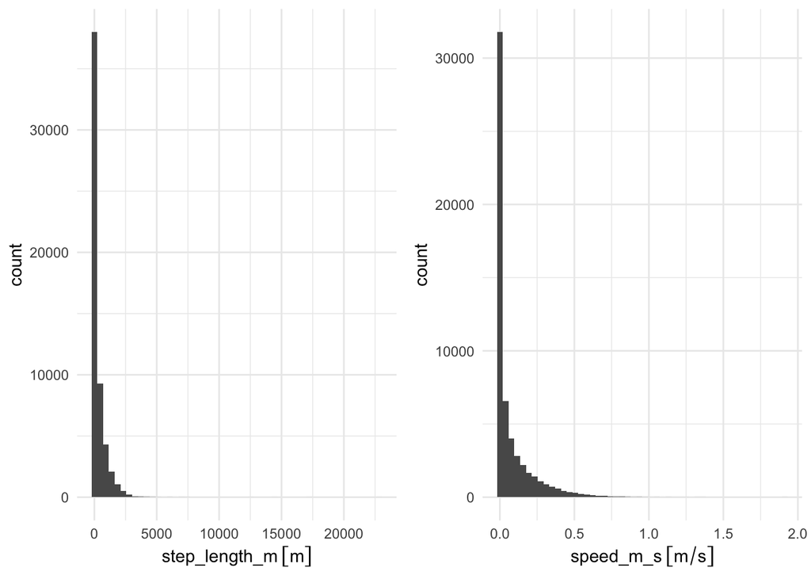

```r
dat.mv <- dat.mv %>%
  mutate(
    step_length_m = mt_distance(., units = "m"),
    speed_m_s = mt_speed(., units = "m/s")
  )

p1 <- dat.mv %>% ggplot(aes(x = step_length_m)) +
  geom_histogram(bins = 50) +
  theme_minimal()
p2 <- dat.mv %>% ggplot(aes(x = speed_m_s)) +
  geom_histogram(bins = 50) +
  theme_minimal()
grid.arrange(p1, p2, ncol = 2)
```

For speed and step length, it is often helpful to look at the log scale.

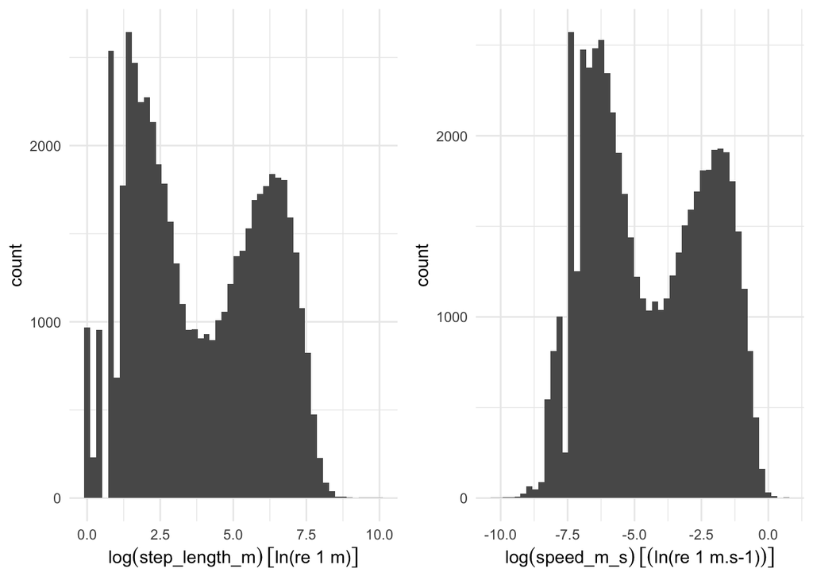

```r
p3 <- dat.mv %>% ggplot(aes(x = log(step_length_m))) +
  geom_histogram(bins = 50) +
  theme_minimal()
p4 <- dat.mv %>% ggplot(aes(x = log(speed_m_s))) +
  geom_histogram(bins = 50) +
  theme_minimal()
grid.arrange(p3, p4, ncol = 2)
```

Very interesting twin-peak pattern of cougar activity! This indicates that cougar could have two different movement states.

**TASK 1:** make a map of cougar movement, color the tracking location by speed. This would be a good way to explore the movement pattern further. Based on this map, is there any obvious pattern that could explain the distribution of step length and speed?

## heading and turning angles

Turning angles are a property of 2 segments (3 locations), and angles are calculated in radians relative to the previous step, with 2 NAs per track (first and last value of each track).

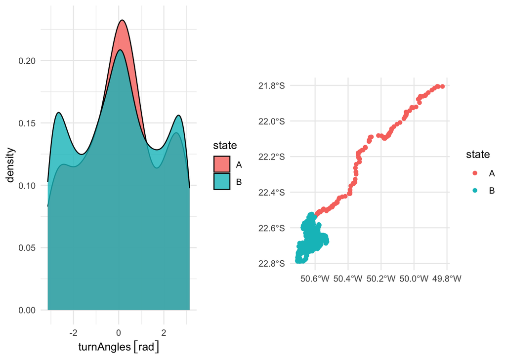

```r
dat.mv <- dat.mv %>%
  st_transform(., 4326) %>% # then the angle calculation require geographic coordinate system again
  mutate(turnAngles = mt_turnangle(.),
         heading = mt_azimuth(.))

p5 <- dat.mv %>%
  filter(individual_local_identifier %in% c("Piloto"),
         timestamp > ymd("2019-03-24")) %>%
  mutate(state = ifelse(timestamp < ymd("2019-04-08"), "A", "B") ) %>%
  ggplot(aes(x = turnAngles, fill = state)) +
  geom_density(alpha = 0.8) +
  theme_minimal()

p6 <- dat.mv %>%
  filter(individual_local_identifier %in% c("Piloto"),
         timestamp > ymd("2019-03-24")) %>%
  mutate(state = ifelse(timestamp < ymd("2019-04-08"), "A", "B") ) %>%
  ggplot(aes(color = state)) + geom_sf() +
  theme_minimal()

grid.arrange(p5, p6, ncol = 2)
```

Turn angle distributions are different for Piloto at the two different movement sections. Hence, tun angle could be used as one of the metrics to characterize movement patterns. We will talk more about this later.

`move2` certain has its advantage due to its integration with movebank. The calculation of metrics are also intuitive. However, the metrics calculation might not be the most straightforward in terms of the different requirements in the coordinate reference systems. Next, we will introduce a different package with a cleaner workflow (but with its own limitation, which we will talk more about below).

# Step-level metrics with `amt`

The amt package (Animal Movement Tools) provides a comprehensive and flexible framework for analyzing animal movement data. One of its key strengths lies in its tidy, modular approach to constructing movement workflows—enabling users to easily calculate movement metrics, generate random steps, and fit step-selection functions. In contrast to packages that emphasize trajectory visualization or raw data handling, `amt` is designed to support hypothesis-driven analysis, especially in the context of habitat selection and movement ecology. Today we will focus on the metrics part of the workflow.

For this part, let’s use the wildebeest data.

```r
load("./Data/wildebeest_data.rdata")
```

## step 1: data cleaning and track generation

Because of the hypothesis-driven workflow, `amt` has requirement for data quality, and the first step is data cleaning, including: 1. check whether the data set contains any missing location coordinates. If so, remove the incomplete relocation; 2. make sure a time stamp (date + time) column exist; 3. check for and remove any duplicated time stamps.

```r
# check is all observations are complete
WB <- WB %>%
  as_tibble() %>%
  filter(
    fixType == "3D" & as.numeric(DOP) < 10 | fixType == "2D" & as.numeric(DOP)  < 5)

all(complete.cases(WB))
```

```
## [1] TRUE
```

Cool. All cases are complete.

Now check whether any time stamps are duplicated for each individual:

```r
WB %>% group_by(animal_id) %>% summarise(any(duplicated(timestamp)))
```

```
## # A tibble: 12 × 2
##    animal_id `any(duplicated(timestamp))`
##    <fct>     <lgl>
##  1 Karbolo   FALSE
##  2 Kikaya    FALSE
##  3 Kiranto   FALSE
##  4 Laingoni  FALSE
##  5 Ne Mpaash FALSE
##  6 Noontare  FALSE
##  7 Ntishya   FALSE
##  8 Ole Nagol FALSE
##  9 Paita     FALSE
## 10 Peria     FALSE
## 11 Sawani    FALSE
## 12 Sotua     FALSE
```

We have no duplicated timestamp within each individual. Great!

## step 2: track creation

Like other packags, track is the base unit how `amt` handles movement data. Basically you tell `amt` which columns from the input data frame are locations, time, and individual ID (if exists), and any other associated information.

```r
wb.trk <- make_track(WB,
                            # tell the function which column contains the coordinates
                            .x = longitude, .y = latitude,
                            # tell the function which CRS the coordinates are based on.
                            crs = 4326,
                            .t = timestamp,
                            # any additional information you want to attach to the track
                            # such as animal ID and month
                            id = animal_id, sex = sex, temp = temp)

class(wb.trk)
```

```
## [1] "track_xyt"  "track_xy"   "tbl_df"     "tbl"        "data.frame"
```

Now we have a movement track. But at the same time it is still a tibble. Hence, the pipe operations from `dyplr` still work for tracks created by `amt`.

We can use function `summarize_sampling_rate` to look at the sampling rate.

```r
summarize_sampling_rate(wb.trk)
```

```
## # A tibble: 1 × 9
##     min    q1 median  mean    q3    max    sd     n unit
##   <dbl> <dbl>  <dbl> <dbl> <dbl>  <dbl> <dbl> <int> <chr>
## 1     0     0      0  679.     0 259200 2309. 99376 sec
```

## step 3: calculating step-level metrics

Like `move2`, `amt` can calculate basic movement metrics. Uniquely, `amt` provides us a quick and elegant way to calculate common step statistics all at once.

Because we want to calculate steps lengths, transform it to projected coordinate system first so the calculate unite would be in meters.

```r
wb.trk.UTM <- transform_coords(wb.trk, 32737)
```

Let’s start with one individual.

```r
# first we filter the data to the individual of interest
one.wb.trk.UTM <- wb.trk.UTM %>% filter(id == "Sotua")

one.wb.steps <- steps(one.wb.trk.UTM)

head(one.wb.steps)
```

```
## # A tibble: 6 × 10
##       x1_     x2_      y1_      y2_   sl_ direction_p    ta_ t1_
## *   <dbl>   <dbl>    <dbl>    <dbl> <dbl>       <dbl>  <dbl> <dttm>
## 1 260296. 260329. 9849694. 9849518. 179.       -1.38  NA     2010-10-15 16:00:00
## 2 260329. 260393. 9849518. 9849505.  65.1      -0.201  1.18  2010-10-15 17:00:00
## 3 260393. 260432. 9849505. 9849416.  97.6      -1.15  -0.951 2010-10-15 18:00:00
## 4 260432. 260499. 9849416. 9849319. 118.       -0.965  0.187 2010-10-15 21:00:00
## 5 260499. 260365. 9849319. 9849360. 140.        2.85  -2.47  2010-10-16 00:00:00
## 6 260365. 260066. 9849360. 9849895. 613.        2.08  -0.765 2010-10-16 03:00:00
## # ℹ 2 more variables: t2_ <dttm>, dt_ <drtn>
```

As demonstrated, using `steps()`, we can quickly calculate all the common step statistics for a track, in which `x1_` and `y1_` are the coordinates of the first location, and `x2_` and `y2_` are the coordinate of the second location. In the new tibble, we see the step length `sl_`, turning angle `ta_`, and step duration `dt_`.

## Working with several individuals concurrently

We often want movement characteristics calculated for several animals/tracks together. `amt` does not provide a infrastructure for dealing with several animal. However, list-columns from the `tidyverse` can be used to manage many animals.

Because a track is just a tibble all tidyverse verbs can be used. The general strategy consists of three steps:

**1.** Nest a track by one or more columns (such as by ID). A nested data frame is a data frame where one (or more) columns is a list of data frames (hence basically tibble nested in a tibble).

```r
wb.trk.nested <- wb.trk.UTM %>% nest(data = -"id")

wb.trk.nested
```

```
## # A tibble: 12 × 2
##    id        data
##    <fct>     <list>
##  1 Sotua     <trck_xyt [4,809 × 5]>
##  2 Laingoni  <trck_xyt [7,806 × 5]>
##  3 Noontare  <trck_xyt [11,095 × 5]>
##  4 Ne Mpaash <trck_xyt [7,353 × 5]>
##  5 Ole Nagol <trck_xyt [1,110 × 5]>
##  6 Kiranto   <trck_xyt [11,974 × 5]>
##  7 Paita     <trck_xyt [11,114 × 5]>
##  8 Karbolo   <trck_xyt [6,084 × 5]>
##  9 Ntishya   <trck_xyt [11,837 × 5]>
## 10 Peria     <trck_xyt [11,840 × 5]>
## 11 Sawani    <trck_xyt [3,586 × 5]>
## 12 Kikaya    <trck_xyt [10,769 × 5]>
```

Individual tracks are now stored is now stored in a new column called “data”.

**2.** Now we can perform operations on the grouped data by using `mutate` and `map`. *`map` applies a function to each elephant of a vector/list.*

```r
wb.step.nested <- wb.trk.nested %>% mutate (steps = map(data, function(x) {x %>% steps()} ))

wb.step.nested
```

```
## # A tibble: 12 × 3
##    id        data                    steps
##    <fct>     <list>                  <list>
##  1 Sotua     <trck_xyt [4,809 × 5]>  <stps_xyt [4,808 × 10]>
##  2 Laingoni  <trck_xyt [7,806 × 5]>  <stps_xyt [7,805 × 10]>
##  3 Noontare  <trck_xyt [11,095 × 5]> <stps_xyt [11,094 × 10]>
##  4 Ne Mpaash <trck_xyt [7,353 × 5]>  <stps_xyt [7,352 × 10]>
##  5 Ole Nagol <trck_xyt [1,110 × 5]>  <stps_xyt [1,109 × 10]>
##  6 Kiranto   <trck_xyt [11,974 × 5]> <stps_xyt [11,973 × 10]>
##  7 Paita     <trck_xyt [11,114 × 5]> <stps_xyt [11,113 × 10]>
##  8 Karbolo   <trck_xyt [6,084 × 5]>  <stps_xyt [6,083 × 10]>
##  9 Ntishya   <trck_xyt [11,837 × 5]> <stps_xyt [11,836 × 10]>
## 10 Peria     <trck_xyt [11,840 × 5]> <stps_xyt [11,839 × 10]>
## 11 Sawani    <trck_xyt [3,586 × 5]>  <stps_xyt [3,585 × 10]>
## 12 Kikaya    <trck_xyt [10,769 × 5]> <stps_xyt [10,768 × 10]>
```

```r
# let's look at one element in the column "steps"
wb.step.nested$steps[1]
```

```
## [[1]]
## # A tibble: 4,808 × 10
##        x1_     x2_      y1_     y2_   sl_ direction_p    ta_ t1_
##      <dbl>   <dbl>    <dbl>   <dbl> <dbl>       <dbl>  <dbl> <dttm>
##  1 260296. 260329. 9849694.  9.85e6 179.       -1.38  NA     2010-10-15 16:00:00
##  2 260329. 260393. 9849518.  9.85e6  65.1      -0.201  1.18  2010-10-15 17:00:00
##  3 260393. 260432. 9849505.  9.85e6  97.6      -1.15  -0.951 2010-10-15 18:00:00
##  4 260432. 260499. 9849416.  9.85e6 118.       -0.965  0.187 2010-10-15 21:00:00
##  5 260499. 260365. 9849319.  9.85e6 140.        2.85  -2.47  2010-10-16 00:00:00
##  6 260365. 260066. 9849360.  9.85e6 613.        2.08  -0.765 2010-10-16 03:00:00
##  7 260066. 259959. 9849895.  9.85e6 139.        2.44   0.359 2010-10-16 06:00:00
##  8 259959. 259885. 9849984.  9.85e6 186.       -1.98   1.86  2010-10-16 07:00:00
##  9 259885. 259962. 9849813.  9.85e6  99.4      -0.696  1.28  2010-10-16 08:00:00
## 10 259962. 260068. 9849750.  9.85e6 107.       -0.139  0.557 2010-10-16 09:00:00
## # ℹ 4,798 more rows
## # ℹ 2 more variables: t2_ <dttm>, dt_ <drtn>
```

**3.** `select()` the relevant columns and `unnest()` to turn the data frame back to a data frame.

Because we are interested in making a steps data frame containing all individuals, we select column “id” and “steps” and unnest them into a new data frame.

```r
wb.step <- wb.step.nested %>%
  select (id, steps) %>% #select the two columns of interest
  unnest(cols = steps) #unnest the steps column

head(wb.step)
```

```
## # A tibble: 6 × 11
##   id       x1_    x2_    y1_    y2_   sl_ direction_p    ta_ t1_
## * <fct>  <dbl>  <dbl>  <dbl>  <dbl> <dbl>       <dbl>  <dbl> <dttm>
## 1 Sotua 2.60e5 2.60e5 9.85e6 9.85e6 179.       -1.38  NA     2010-10-15 16:00:00
## 2 Sotua 2.60e5 2.60e5 9.85e6 9.85e6  65.1      -0.201  1.18  2010-10-15 17:00:00
## 3 Sotua 2.60e5 2.60e5 9.85e6 9.85e6  97.6      -1.15  -0.951 2010-10-15 18:00:00
## 4 Sotua 2.60e5 2.60e5 9.85e6 9.85e6 118.       -0.965  0.187 2010-10-15 21:00:00
## 5 Sotua 2.60e5 2.60e5 9.85e6 9.85e6 140.        2.85  -2.47  2010-10-16 00:00:00
## 6 Sotua 2.60e5 2.60e5 9.85e6 9.85e6 613.        2.08  -0.765 2010-10-16 03:00:00
## # ℹ 2 more variables: t2_ <dttm>, dt_ <drtn>
```

Now steps across all individuals with basic movement metrics calculated are in one big data frame.

We can now more easily compare movement metrics of different individuals. As an example, we can plot the step-length distributions of all individuals concurrently now:

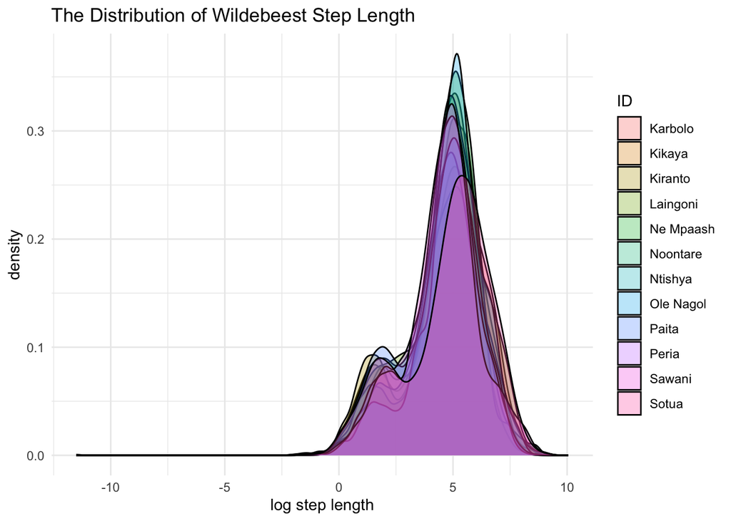

```r
wb.step %>%
  ggplot (aes(x = log(sl_+0.00001), fill = factor(id))) +  #sometimes animals have 0 step length. To avoid issue when doing "log", we can add a very small number to all steps
  geom_density(alpha = 0.3) + #alpha determines transparency
  theme_minimal() +
  labs ( x = "log step length", fill = "ID", title = "The Distribution of Wildebeest Step Length")
```

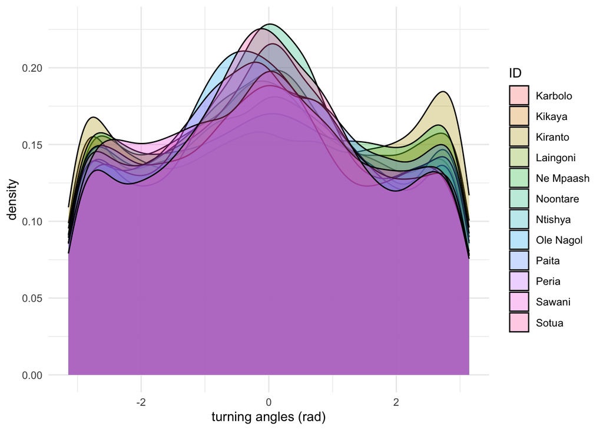

```r
wb.step %>% ggplot (aes(x = ta_, fill = factor(id))) +
  geom_density(alpha = 0.3) + #alpha determines transparency
  theme_minimal() +
  labs (x = "turning angles (rad)", fill = "ID")
```

We can also plot the turn angle density distribution. This time let’s try to plot them in a circular form and turn the radian to degree for easier interpretation.

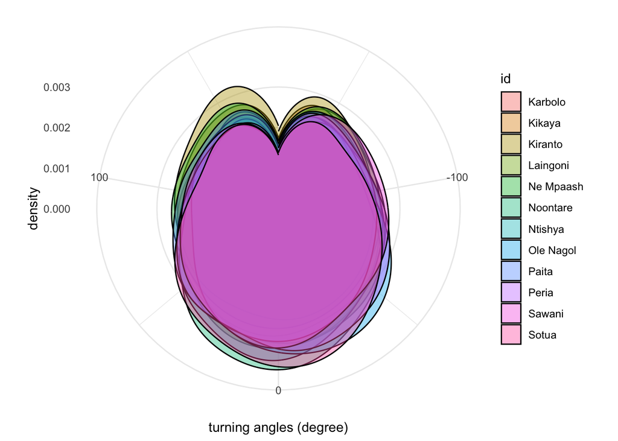

```r
wb.step %>%
  mutate(ta_degree = ta_ * 180/pi) %>%
  filter(!is.na(ta_degree)) %>%
  ggplot(aes(x = ta_degree, fill = id)) +
  geom_density(alpha = 0.4) +
  coord_polar() +
  theme_minimal() +
  labs (x = "turning angles (degree)")
```

# Track-level metrics with `amt`

In addition to these basic step-level metrics (based on the two consecutive steps), `amt` also has functions to calculate other useful track-level metrics (based on multiple steps, i.e. a “track”), such as:

- straightness: the ratio between the distance from the starting point to an end-point and the actual path length traveled between these two points (ranging between 0 and 1, a value of 1 means moving straight);
- mean turn angle correlation (tac): another measure for how straight or tortuous a movement path is. High positive correlation indicates directional persistence whereas low or negative correlation (i.e., large or highly variable turning angles) suggests random movement, often associated with area-restricted search or foraging.
- net squared displacement (nsd): Quantifies the net squared distance traveled over time compared to an point of reference (calculates distance from each location to a point of reference). Often used to identify and characterize animal migration patterns.
- intensity use: calculated by dividing the total movement distance by the square of the area of movement (100% MCP)

`amt` provides functions to directly calculate some of these common metrics. As an example:

```r
wb.trk.nested  <-  wb.trk.nested %>% mutate (
  tot_dist = map_dbl(data, function(x) {x %>% tot_dist()}),
  straightness = map_dbl(data, function(x) {x %>% straightness()}),
  intensity_use = map_dbl(data, function(x) {x %>% intensity_use()}))
wb.trk.nested
```

```
## # A tibble: 12 × 5
##    id        data                    tot_dist straightness intensity_use
##    <fct>     <list>                     <dbl>        <dbl>         <dbl>
##  1 Sotua     <trck_xyt [4,809 × 5]>    10556.     0.00579          102.
##  2 Laingoni  <trck_xyt [7,806 × 5]>     2125.     0.000846         189.
##  3 Noontare  <trck_xyt [11,095 × 5]>    6165.     0.00205          170.
##  4 Ne Mpaash <trck_xyt [7,353 × 5]>      903.     0.000555         212.
##  5 Ole Nagol <trck_xyt [1,110 × 5]>     1263.     0.00389           59.6
##  6 Kiranto   <trck_xyt [11,974 × 5]>     388.     0.000160         123.
##  7 Paita     <trck_xyt [11,114 × 5]>    2083.     0.000862         359.
##  8 Karbolo   <trck_xyt [6,084 × 5]>     1584.     0.000848         225.
##  9 Ntishya   <trck_xyt [11,837 × 5]>   16281.     0.00510          136.
## 10 Peria     <trck_xyt [11,840 × 5]>    3036.     0.00115          146.
## 11 Sawani    <trck_xyt [3,586 × 5]>     8508.     0.00815           48.4
## 12 Kikaya    <trck_xyt [10,769 × 5]>   25434.     0.00855          133.
```

Now you get a quick overview of the different movement patterns across different individuals. For example, some individuals moved more distances than others (but not that the tracking duration might be different), and others use space more intensely than others.

You can also calculate NSD with `amt`:

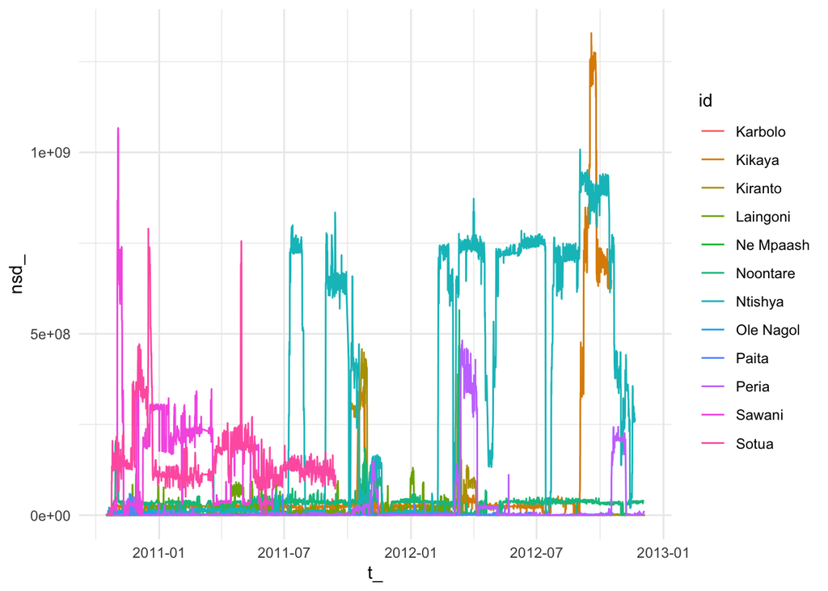

```r
wb.trk.nsd <- wb.trk.nested %>%
  mutate (data = map(data, function(x) {x %>% add_nsd()})) %>%
  select (id, data) %>% #select the two columns of interest
  unnest(cols = data)

p_nsd <- wb.trk.nsd %>% ggplot(aes(x = t_, y = nsd_, color = id)) +
  geom_line() +
  theme_minimal()
p_nsd
```

**QUESTION 1:** How would you interpret the movement pattern of these wildebeest? Consider the temporal scale and individual variation.

Further readings:

- Seidel, Dana Paige, Eric Dougherty, Colin Carlson, and Wayne M. Getz. 2018. “Ecological Metrics and Methods for GPS Movement Data.” International Journal of Geographical Information Science: IJGIS 32 (11): 2272–93.
- Abrahms, Briana, Dana P. Seidel, Eric Dougherty, Elliott L. Hazen, Steven J. Bograd, Alan M. Wilson, J. Weldon McNutt, et al. 2017. “Suite of Simple Metrics Reveals Common Movement Syndromes across Vertebrate Taxa.” Movement Ecology 5 (June): 12.
- Kays, Roland, Ben Hirsch, Damien Caillaud, Rafael Mares, Shauhin Alavi, Rasmus Worsøe Havmøller, and Margaret Crofoot. 2023. “Multi-Scale Movement Syndromes for Comparative Analyses of Animal Movement Patterns.” Movement Ecology 11 (1): 61.

—————– (ﾉ◕ヮ◕)ﾉ*:･ﾟ✧ THE END :･ﾟ･ﾟ ——————